# 드디어 CCTV현황을 그래프로!

드디어 matplotlib를 이용해 데이터를 시각화 해 줄 수 있지만, 아직 한글 처리 문제가 남아있습니다. 기본적으로 matplot은 한글 폰트를 지원 하지 않기 때문에 matplotlib의 폰트부터 변경 시켜 보겠습니다. 순서는 다음과 같습니다.

1. platform 모듈 임포트 하기
   - OS를 구분 해 줄 수 있습니다.
2. matplotlib 모듈 임포트 하기
   - 시각화를 하기 위함이겠죠?
3. OS를 구분하여 폰트를 각각 설정해 줍니다.

```python
import platform #os 정보를 가져 올 수 있는 모듈

from matplotlib import font_manager, rc # font_manager : 폰트 관리 모듈, rc : 폰트 변경 모듈
from matplotlib import pyplot as plt # 시각화 도구
%matplotlib inline
plt.rcParams['axes.unicode_minus'] = False # 유니코드 표현 설정하기


if platform.system() == 'Darwin':
    rc('font', family='AppleGothic') # OS가 APPLE(Darwin)이면 AppleGothic으로 폰트 설정
elif platform.system() == 'Windows':
    path="c:/Windows/Fonts/malgun.ttf" #OS가 윈도우즈면 맑은 고딕으로 설정
    font_name = font_manager.FontProperties(fname=path).get_name()
    rc('font', family=font_name)
else:
    print('Unknown System... sorry~~~~')
```

폰트 설정이 끝났으면 다시 한번 data_result를 확인 해보겠습니다

```python
data_result.head()
```

| 구별 | 소계 | 최근증가율 | 인구수 | 한국인 | 외국인 | 고령자 | 외국인비율 | 고령자비율 |
| --- | --- | --- | --- | --- | --- | --- | --- | --- |
| 강남구 | 2780 | 150.619195 | 570500.0 | 565550.0 | 4950.0 | 63167.0 | 0.867660 | 11.072217 |
| 강동구 | 773 | 166.490765 | 453233.0 | 449019.0 | 4214.0 | 54622.0 | 0.929765 | 12.051638 |
| 강북구 | 748 | 125.203252 | 330192.0 | 326686.0 | 3506.0 | 54813.0 | 1.061806 | 16.600342 |
| 강서구 | 884 | 134.793814 | 603772.0 | 597248.0 | 6524.0 | 72548.0 | 1.080540 | 12.015794 |
| 관악구 | 1496 | 149.290780 | 525515.0 | 507203.0 | 18312.0 | 68082.0 | 3.484582 | 12.955291 |

pandas 데이터에 바로 plot 명령을 이용해 데이터를 바로 그려 볼 수 있습니다.

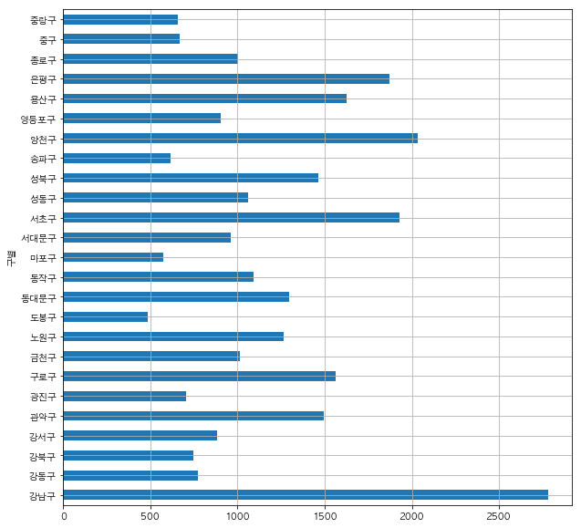

```python
data_result['소계'].plot(kind='barh', grid=True, figsize=(10,10)) #barh 형태 그래프, grid 생성
plt.show()
```

정렬 해서 보는 것이 조금 더 좋겠네요!

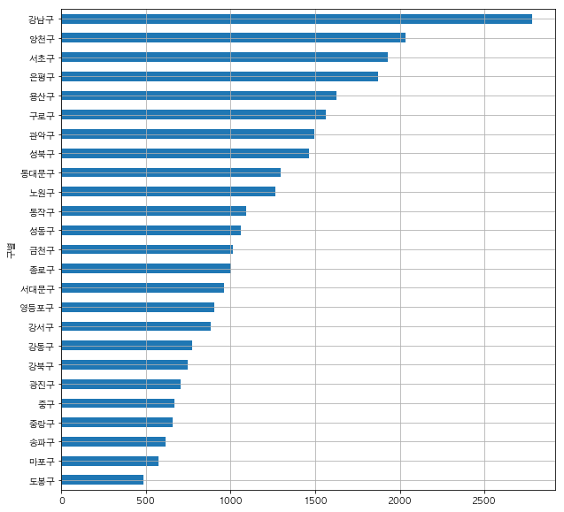

```python
data_result['소계'].sort_values().plot(kind='barh', grid=True, figsize=(10,10)) #barh 형태 그래프, grid 생성
plt.show()
```

# 자! 시각화 되었으니 다시한번 분석해 보겠습니다. 이번엔 비율입니다

먼저 시각화 되어있는 그래프를 보면 CCTV 개수 자체는 강남구가 월등하게 많은 것이 확인됩니다. 또한 가장 CCTV가 많이 없는 그룹도 보이네요!  
이어서 인구대비 CCTV 비율을 계산 해 보겠습니다. 간단하게 **소계 / 인구수 * 100** 을 하면 될 것 같습니다.

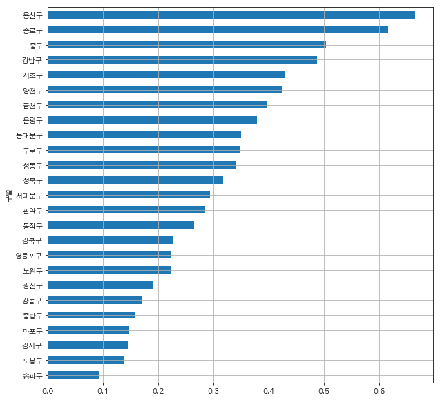

```python
data_result['CCTV비율'] = data_result['소계'] / data_result['인구수'] * 100
data_result['CCTV비율'].sort_values().plot(kind='barh', grid=True, figsize=(10,10))

plt.show()
```

인구수 대비 CCTV수는 용산구와 종로구가 제일 많은 것이 확인 됩니다. 송파구는 여전히 인구수로 비교하나, 소계로 비교하나 최 하위권을 차지 하고 있네요.  
어느 정도 분석은 된 것 같지만 조금 더 자세히 시각화 해 보겠습니다. scatter를 활용해 보겠습니다.

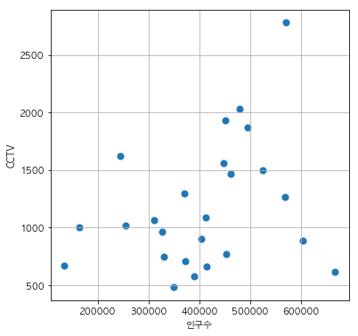

```python
plt.figure(figsize=(6,6))
plt.scatter(data_result['인구수'], data_result['소계'], s=50)
plt.xlabel('인구수')
plt.ylabel('CCTV')
plt.grid()
plt.show()
```

표시한 데이터를 대표 할 수 있는 직선을 하나 그려 보겠습니다.  
직선의 용도는 인구수가 많아질 수록 CCTV의 설치량은 많이 지는 것을 한 눈에 알아 볼 수 있게 해 줄것입니다.(방금전의 비율과는 무관합니다)  
그리고 지금 그려볼 이 직선이 인구별 CCTV에 대한 **기준**이 될 것입니다.

```python
fp1 = np.polyfit(data_result['인구수'], data_result['소계'], 1) #인구수, 소계에 따른 기준 직선 만들어 내기
fp1 # 이 값이 인구별 CCTV의 기준에 대한 선이 됩니다
```

```
array([  1.30916415e-03,   6.45066497e+02])
```

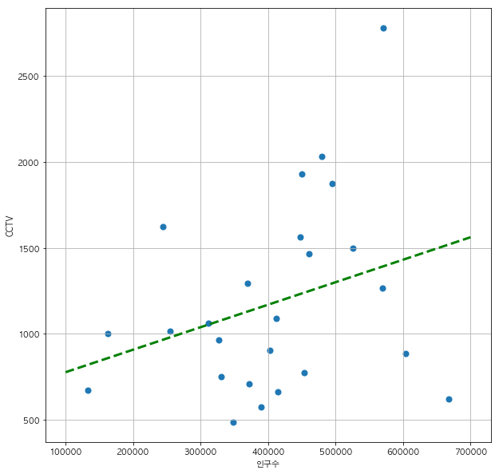

```python
f1 = np.poly1d(fp1) # y축 데이터 만들기(CCTV 개수 표현을 위한 데이터 축)
fx = np.linspace(100000,700000,100) # x축 데이터 만들기 (인구수 표현을 위한 데이터 축)

plt.figure(figsize=(10,10))
plt.scatter(data_result['인구수'], data_result['소계'], s=50)
plt.plot(fx, f1(fx), ls='dashed', lw=3, color='g') # 기준 직선 그려주기
plt.xlabel('인구수')
plt.ylabel('CCTV')
plt.grid()
plt.show()
```

이제 이 그래프의 직선은 구별 CCTV의 기준값이 됩니다. 이 때 우리가 기준으로 삼을 수 있는 조건은 이 **직선에 가장 근접한 점**을 찾아보면 됩니다.  
확인 해 보니 대략 300,000만명의 인구수 일 때 1,100개의 CCTV가 기준이 된다 라고 볼 수 있겠네요  
그렇다면 이 직선을 기준으로 해서 멀리 떨어져 있다는 것은 **비정상적으로 많거나 적다**라는 겁니다.

- 직선 보다 위에 있을 수록 CCTV가 인구수에 비해 과하게 설치 되었다는 것이고
- 직선 보다 아래에 있을 수록 CCTV가 인구수에 비해 부족하다는 뜻이 됩니다.

직선과 멀리 떨어질 수록 색상도 다르게 표현해주고, 기준점에서 많이 벗어난 구의 이름을 표시 해 보겠습니다.  
따라서 직선과의 오차를 구하는 코드를 작성하고, 오차가 큰 순으로 데이터를 정렬해서 그래프를 그려 보겠습니다.

```python
fp1 = np.polyfit(data_result['인구수'], data_result['소계'], 1) # 기준선 구하기

f1 = np.poly1d(fp1) # CCTV 기준치 구하기 (y 축)
fx = np.linspace(100000,700000, 100) # 인구수 (x 축)

data_result['오차'] = np.abs(data_result['소계'] - f1(data_result['인구수'])) # 소계에서 기준 인구수 차이 -> 오차값 구하기

df_sort = data_result.sort_values(by='오차', ascending=False)
df_sort.head()
```

| 구별 | 소계 | 최근증가율 | 인구수 | 한국인 | 외국인 | 고령자 | 외국인비율 | 고령자비율 | CCTV비율 | 오차 |
| --- | --- | --- | --- | --- | --- | --- | --- | --- | --- | --- |
| 강남구 | 2780 | 150.619195 | 570500.0 | 565550.0 | 4950.0 | 63167.0 | 0.867660 | 11.072217 | 0.487292 | 1388.055355 |
| 송파구 | 618 | 104.347826 | 667483.0 | 660584.0 | 6899.0 | 72506.0 | 1.033584 | 10.862599 | 0.092587 | 900.911312 |
| 양천구 | 2034 | 34.671731 | 479978.0 | 475949.0 | 4029.0 | 52975.0 | 0.839413 | 11.036964 | 0.423769 | 760.563512 |
| 서초구 | 1930 | 63.371266 | 450310.0 | 445994.0 | 4316.0 | 51733.0 | 0.958451 | 11.488308 | 0.428594 | 695.403794 |
| 용산구 | 1624 | 53.216374 | 244203.0 | 229456.0 | 14747.0 | 36231.0 | 6.038828 | 14.836427 | 0.665020 | 659.231690 |

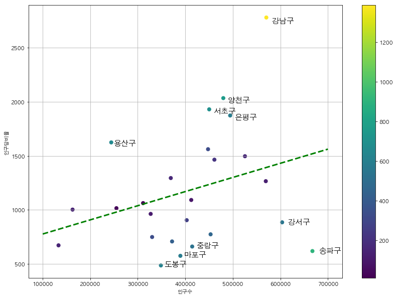

```python
#텍스트와 colormap 입히기
plt.figure(figsize=(14,10))
plt.scatter(data_result['인구수'], data_result['소계'], c=data_result['오차'], s=50)
plt.plot(fx, f1(fx), ls='dashed', lw=3, color='g') #x축 기준 인구수, y축 기준 CCTV 대수

#오차가 가장 큰 10개의 구에 대해서 텍스트 부여하기
for n in range(10):
    #scatter가 찍힌 좌표에 적당히 거리를 조절하여 해당하는 데이터의 인덱스(df_sort.index[n])를 출력하기
    plt.text(df_sort['인구수'][n]*1.02, df_sort['소계'][n] * 0.98, df_sort.index[n], fontsize=15)

plt.xlabel('인구수')
plt.ylabel('인구당비율')

plt.colorbar()
plt.grid()
plt.show()
```

# 결론

직선을 기준으로 해서 위에 있는 강남구, 양천구, 서초구, 은평구, 용산구는 서울시 전체 지역의 일반적인 경향보다 CCTV가 많이 설치 되어 있습니다.  
그리고 송파고, 강서구, 중랑구, 마포구, 도봉구는 일반적인 경향보다 CCTV가 적게 설치 된 지역 입니다.

### 특히

- 강남구는 월등히 많은 CCTV를 보유 하고 있고
- 송파구는 매우 부족한 CCTV를 보유 하고 있다

라고 결론을 내려 볼 수 있겠습니다.

어려우셨나요? 사실 scatter그래프를 이용해서 분석 한 내용은 정말 고급스러운(어려운) 내용입니다.  
다음장은 CCTV의 대수가 범죄율에 영향을 미칠까? 라는 의문을 가지고 데이터 분석을 실시 해보겠습니다.